# EM-analysis

Importing packages:

There are functions hiding here…

And a script hiding here…

`means` contains the mean vitelline membrane width for each image. `agg_means` contains the mean widths for each biological replicate.

The terminal ends of the oocytes look odd- the *tsl-* ones have a very thick vitelline membrane in places. This is odd, so I excluded that data.

The data is *just* significant, using our three biological replicates. If we treat each image as a biological replicate, the data becomes very significant. (I did this as an idiocy check.) This is not very convinving. I also calculated the effect size using the Cohen’s d test. (Unsure if this is appropriate.) The effect size is large: -2.4179685 for biological replicates and -1.6155525 for technical replicates.

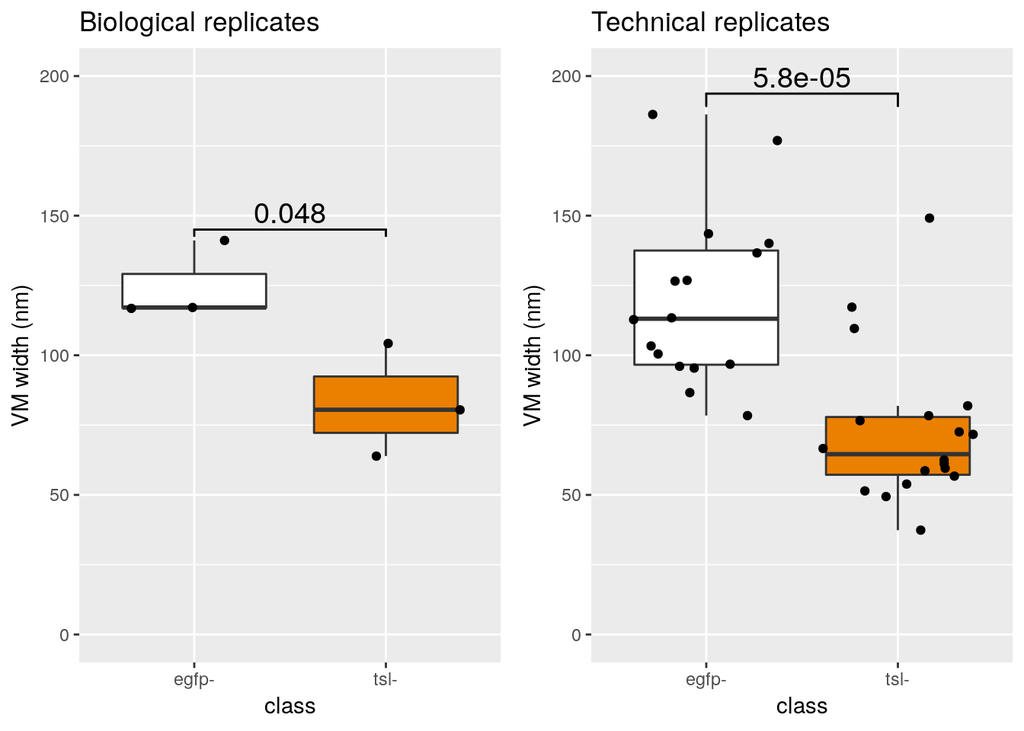

However, there are several gaps in the vitelline membrane- let’s quantify those.

This does come out as “statistically significant”- see plot below. The effect size is large: 4.1116166.

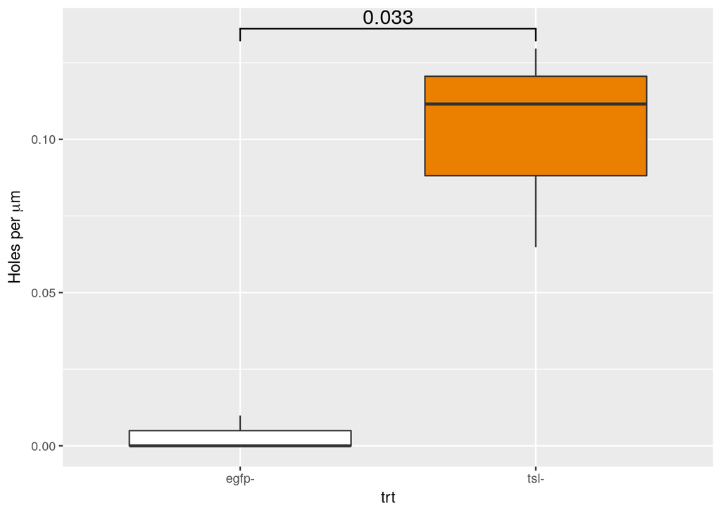

I’ve plotted the edge values I excluded. The *tsl-* values are highly variable, but there doesn’t seem to be an aboslute difference in mean VM width. Note that for these data, I had to treat technical replicates as biological replicates, as some biological replicates completely lacked data points. This is acceptable, as I’m only trying to get a feel for the data.

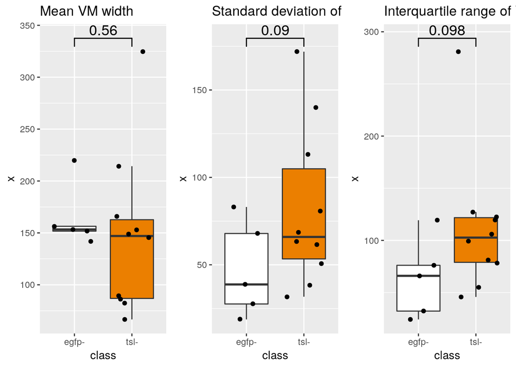